# Data Analytics

2024-05-10

## Assignment 4

## 20182543

### 가석방 위반자 예측

교도소의 수감자들이 일정 기간 수감 후 심사를 거쳐 정해진 형기를 채우지 않고 석방되는 것을 가석방이라 한다.가석방된 수감자는 남은 형기를 교도소 밖에서 보내지만, 가석방 기간 중 다시 범죄를 저지르는 등 가석방의 조건을 위반하는 경우 다시 교도소로 돌아오기도 한다.

parole_violator.csv는 2010년 미국에서 가석방된 수감자 중 교도소 복역 기간이 6개월 이하이며 범죄로 인한 총 형량이 18개월 이하인 사람들에 대한 다음 데이터를 포함한다.

• Male : 성별 (1:남성, 0:여성)

• RaceWhite : 인종(1:백인, 0:백인 외)

• Age : 수감자의 가석방 시의 나이

• State : 수감자의 state (Kentucky, Louisiana, Virginia, Other)

• TimeServed : 수감 기간 (단위: 개월)

• MaxSentence : 수감자의 형량 (단위: 개월)

• MultipleOffenses : 중복 범죄 여부 (1: 여러 범죄로 수감, 0: 하나의 범죄로 수감)

• Crime: 범죄 유형 (Larceny-절도, Drugs-마약, Driving-음주운전, Other-기타)

• Violator : 가석방 조건 위반 여부 (1:가석방 중 조건 위반, 0: 위반 없이 가석방 기간 종료)

위의 수감자의 정보를 활용하여, 수감자가 가석방된 후 가석방 조건을 위반하는지 여부를 예측하는 모델을 수립하고자 한다.

```r
# 사용할 패키지 추가
library(mice)
library(dplyr)
library(ggplot2)
library(readr)
library(visdat)
library(psych)
library(rsample)
library(caret)
library(glmnet)
library(ROCR)
library(e1071)
```

데이터셋에 결측치가 있는지 확인한다. 시각화를 통해 어떠한 변수에 어느 정도의 결측치가 있는지 확인해보고, imputation 과정을 통해 결측치를 적절한 값으로 대체시킨다. 간단하게 다음과 같이 micepackage를 활용하자.

데이터 불러오기

```r
df = read.csv("parole_violator.csv")
str(df)
```

```
## 'data.frame':    675 obs. of  9 variables:
##  $ Male            : int  1 0 1 1 1 1 1 0 0 1 ...
##  $ RaceWhite       : int  1 1 0 1 0 0 1 1 1 0 ...
##  $ Age             : num  33.2 39.7 29.5 22.4 21.6 46.7 31 24.6 32.6 29.1 ...
##  $ State           : chr  "Other" "Other" "Other" "Other" ...
##  $ TimeServed      : num  5.5 5.4 5.6 5.7 5.4 6 6 4.8 NA 4.7 ...
##  $ MaxSentence     : int  18 12 12 18 12 18 18 12 13 12 ...
##  $ MultipleOffenses: int  0 0 0 0 0 0 0 0 0 0 ...
##  $ Crime           : chr  "Driving" "Drugs" "Drugs" "Other" ...
##  $ Violator        : int  0 0 0 0 0 0 0 0 0 0 ...
```

male, racewhite, state, multioffenses, crime, violator 컬럼은 범주형으로 변환

```r
# 범주형으로 변환해야할 컬럼들 factor 로 변환
df$Male <- factor(df$Male)
df$RaceWhite <- factor(df$RaceWhite)
df$State <- factor(df$State)
df$MultipleOffenses <- factor(df$MultipleOffenses)
df$Crime <- factor(df$Crime)
df$Violator <- factor(df$Violator)

str(df)
```

```
## 'data.frame':    675 obs. of  9 variables:
##  $ Male            : Factor w/ 2 levels "0","1": 2 1 2 2 2 2 2 1 1 2 ...
##  $ RaceWhite       : Factor w/ 2 levels "0","1": 2 2 1 2 1 1 2 2 2 1 ...
##  $ Age             : num  33.2 39.7 29.5 22.4 21.6 46.7 31 24.6 32.6 29.1 ...
##  $ State           : Factor w/ 4 levels "Kentucky","Louisiana",..: 3 3 3 3 3 3 3 3 3 3 ...
##  $ TimeServed      : num  5.5 5.4 5.6 5.7 5.4 6 6 4.8 NA 4.7 ...
##  $ MaxSentence     : int  18 12 12 18 12 18 18 12 13 12 ...
##  $ MultipleOffenses: Factor w/ 2 levels "0","1": 1 1 1 1 1 1 1 1 1 1 ...
##  $ Crime           : Factor w/ 4 levels "Driving","Drugs",..: 1 2 2 4 4 1 2 4 2 3 ...
##  $ Violator        : Factor w/ 2 levels "0","1": 1 1 1 1 1 1 1 1 1 1 ...
```

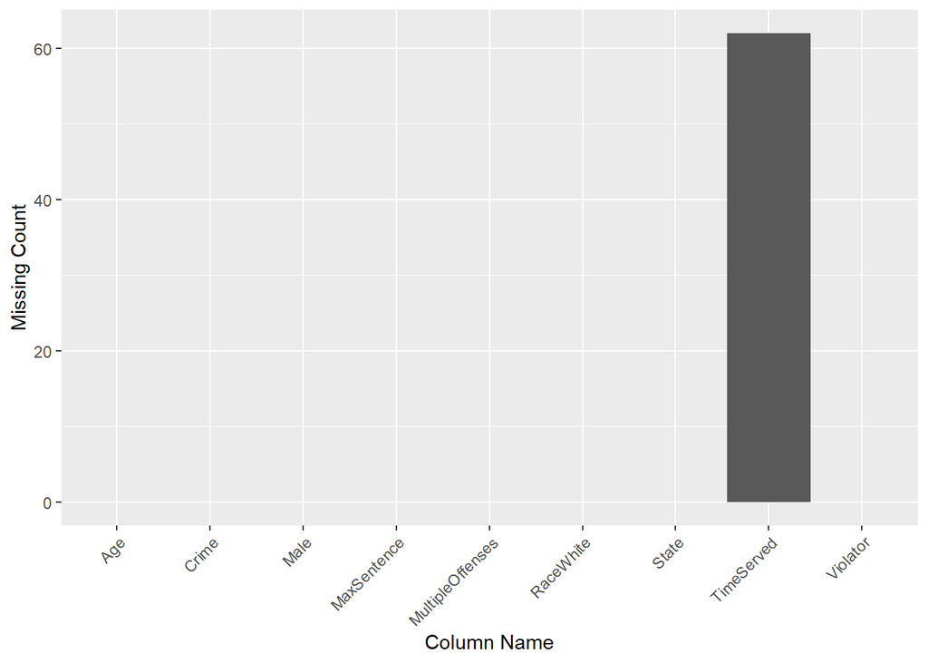

```r
# 데이터프레임에서 결측치 개수 계산
missing_counts <- sapply(df, function(x) sum(is.na(x)))

# 결측치 개수를 데이터프레임으로 변환
missing_df <- data.frame(column_name = names(missing_counts), missing_count = missing_counts)

# 히스토그램 그리기
ggplot(missing_df, aes(x = column_name, y = missing_count)) +
  geom_bar(stat = "identity") +
  labs(x = "Column Name", y = "Missing Count") +
  theme(axis.text.x = element_text(angle = 45, hjust = 1))  # x 축 레이블 각도 설정
```

TimeServed 컬럼에만 결측치가 존재하는 것을 확인했으며, 약 60개 정도의 결측치가 존재한다는 것을 확인할 수 있음

```r
set.seed(123)

df_imp <- complete(mice(df))
str(df_imp)
```

```
## 'data.frame':    675 obs. of  9 variables:
##  $ Male            : Factor w/ 2 levels "0","1": 2 1 2 2 2 2 2 1 1 2 ...
##  $ RaceWhite       : Factor w/ 2 levels "0","1": 2 2 1 2 1 1 2 2 2 1 ...
##  $ Age             : num  33.2 39.7 29.5 22.4 21.6 46.7 31 24.6 32.6 29.1 ...
##  $ State           : Factor w/ 4 levels "Kentucky","Louisiana",..: 3 3 3 3 3 3 3 3 3 3 ...
##  $ TimeServed      : num  5.5 5.4 5.6 5.7 5.4 6 6 4.8 5.1 4.7 ...
##  $ MaxSentence     : int  18 12 12 18 12 18 18 12 13 12 ...
##  $ MultipleOffenses: Factor w/ 2 levels "0","1": 1 1 1 1 1 1 1 1 1 1 ...
##  $ Crime           : Factor w/ 4 levels "Driving","Drugs",..: 1 2 2 4 4 1 2 4 2 3 ...
##  $ Violator        : Factor w/ 2 levels "0","1": 1 1 1 1 1 1 1 1 1 1 ...
```

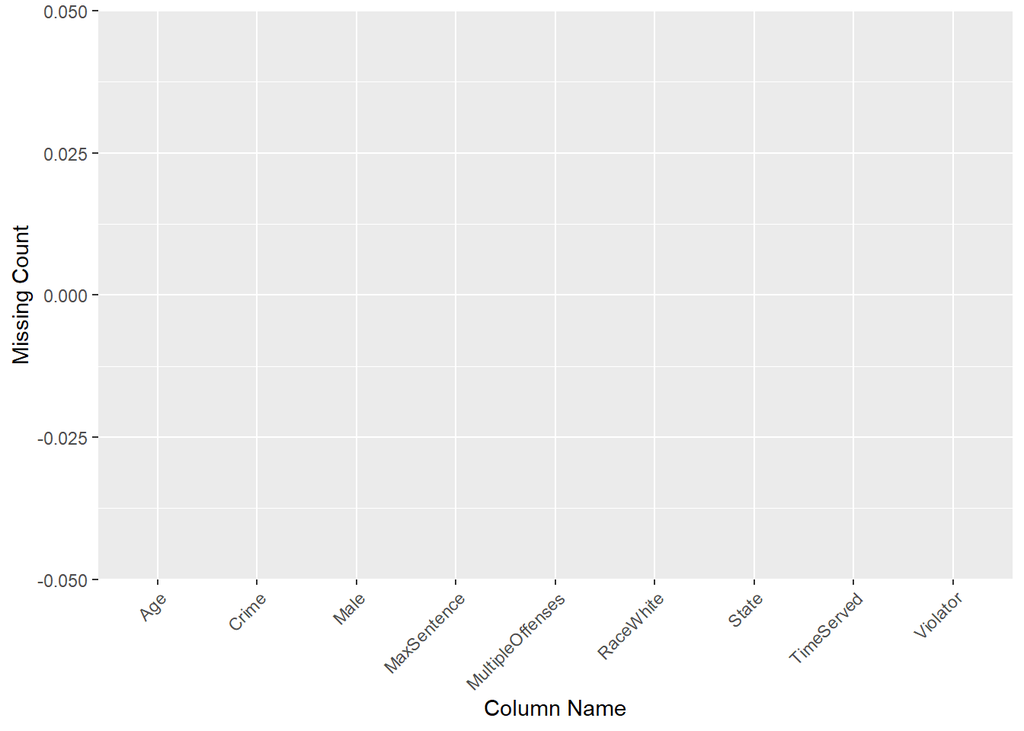

```r
# 데이터프레임에서 결측치 개수 계산
missing_counts_imp <- sapply(df_imp, function(x) sum(is.na(x)))

# 결측치 개수를 데이터프레임으로 변환
missing_df_imp <- data.frame(column_name = names(missing_counts_imp), missing_count = missing_counts_imp)

# 히스토그램 그리기
ggplot(missing_df_imp, aes(x = column_name, y = missing_count)) +
  geom_bar(stat = "identity") +
  labs(x = "Column Name", y = "Missing Count") +
  theme(axis.text.x = element_text(angle = 45, hjust = 1))  # x 축 레이블 각도 설정
```

```r
sum(is.na(df_imp))
```

```
## [1] 0
```

결측치 보간이 제대로 이루어졌음을 확인할 수 있음

그래프를 활용하여 데이터셋을 시각화해보고, 이로부터 변수들의 특성을 분석해보자.

```r
str(df_imp)
```

```
## 'data.frame':    675 obs. of  9 variables:
##  $ Male            : Factor w/ 2 levels "0","1": 2 1 2 2 2 2 2 1 1 2 ...
##  $ RaceWhite       : Factor w/ 2 levels "0","1": 2 2 1 2 1 1 2 2 2 1 ...
##  $ Age             : num  33.2 39.7 29.5 22.4 21.6 46.7 31 24.6 32.6 29.1 ...
##  $ State           : Factor w/ 4 levels "Kentucky","Louisiana",..: 3 3 3 3 3 3 3 3 3 3 ...
##  $ TimeServed      : num  5.5 5.4 5.6 5.7 5.4 6 6 4.8 5.1 4.7 ...
##  $ MaxSentence     : int  18 12 12 18 12 18 18 12 13 12 ...
##  $ MultipleOffenses: Factor w/ 2 levels "0","1": 1 1 1 1 1 1 1 1 1 1 ...
##  $ Crime           : Factor w/ 4 levels "Driving","Drugs",..: 1 2 2 4 4 1 2 4 2 3 ...
##  $ Violator        : Factor w/ 2 levels "0","1": 1 1 1 1 1 1 1 1 1 1 ...
```

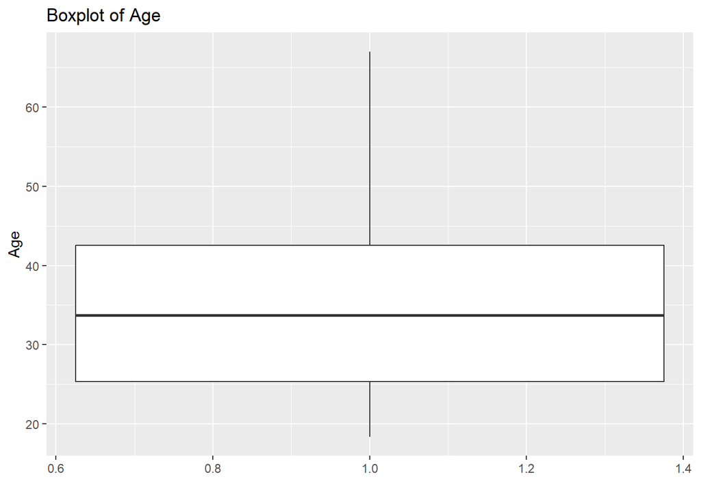

```r
# "Age", "TimeServed", "MaxSentence"에 대한 boxplot 그리기
ggplot(df_imp, aes(x = 1, y = Age)) +
  geom_boxplot() +
  labs(x = "", y = "Age") +
  ggtitle("Boxplot of Age")
```

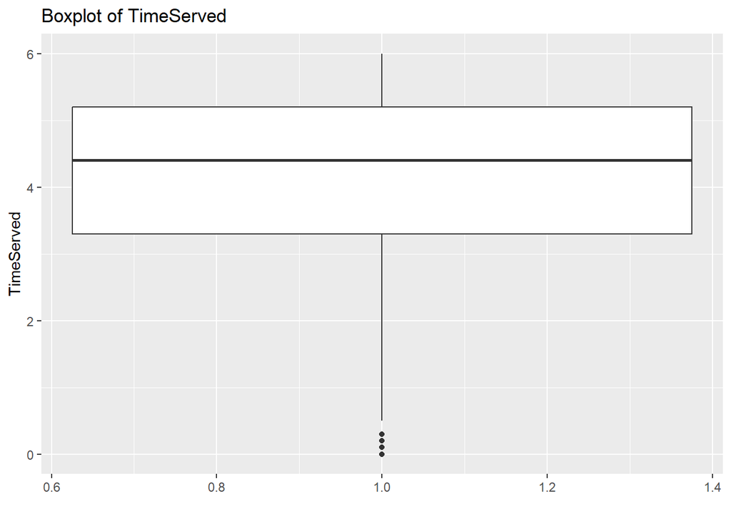

```r
ggplot(df_imp, aes(x = 1, y = TimeServed)) +
  geom_boxplot() +
  labs(x = "", y = "TimeServed") +
  ggtitle("Boxplot of TimeServed")
```

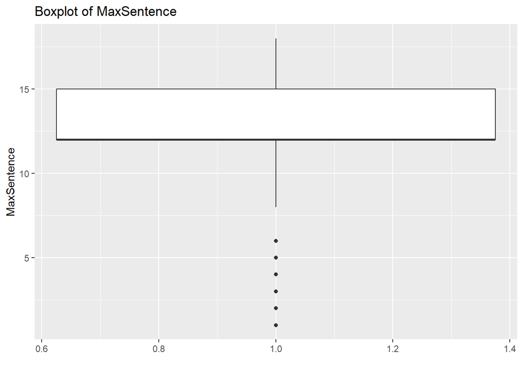

```r
ggplot(df_imp, aes(x = 1, y = MaxSentence)) +
  geom_boxplot() +
  labs(x = "", y = "MaxSentence") +
  ggtitle("Boxplot of MaxSentence")
```

연속형 변수들에 대해서 boxplot을 그렸고 MaxSentence에 이상치가 존재함을 확인하였다.

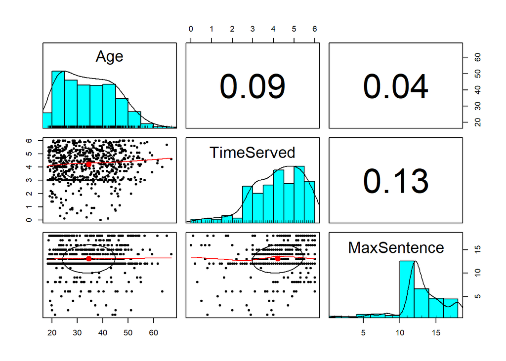

```r
pairs.panels(df_imp[c("Age", "TimeServed", "MaxSentence")])
```

연속형 변수들 간의 상관관계를 그래프로 그려, 변수들 간의 약한 양의 상관관계가 존재함을 확인하였다. 변수들간의 상관관계가 낮아 다중공선성의 증거가 되지 않는다 판단, 연속형 변수들 사이의 다중공선성을 배제하였다.

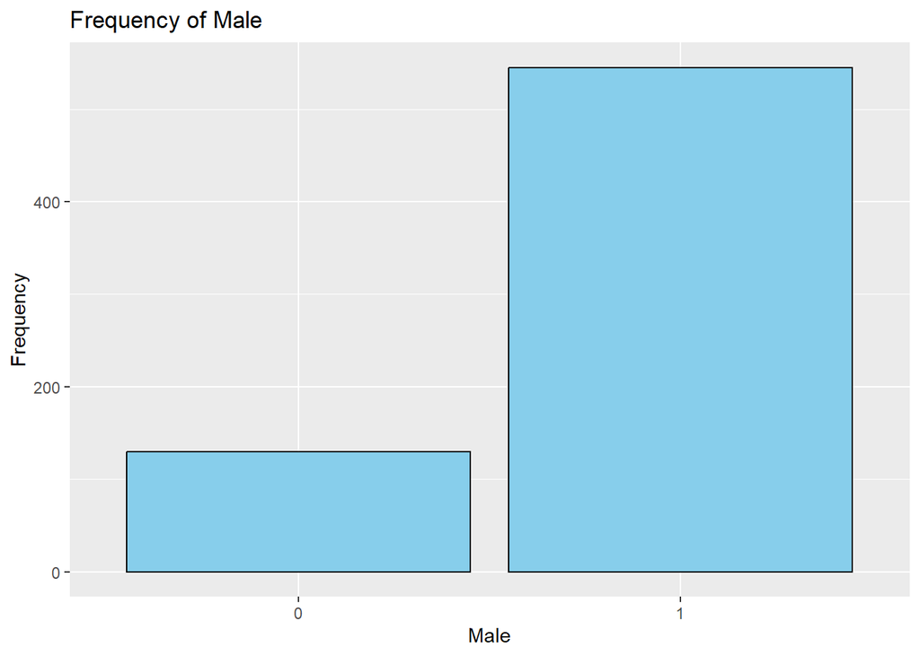

```r
# 'Male' 컬럼의 빈도수를 계산합니다.
male_freq <- table(df_imp$Male)

# 빈도수를 데이터프레임으로 변환합니다.
male_freq_df <- as.data.frame(male_freq)
names(male_freq_df) <- c("Male", "Frequency")

# 히스토그램을 그립니다.
ggplot(male_freq_df, aes(x = Male, y = Frequency)) +
  geom_bar(stat = "identity", fill = "skyblue", color = "black") +
  labs(title = "Frequency of Male", x = "Male", y = "Frequency")
```

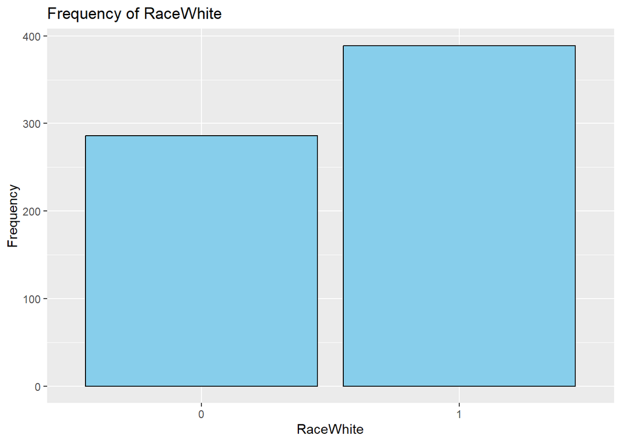

```r
# 'RaceWhite' 컬럼의 빈도수를 계산합니다.
RaceWhite_freq <- table(df_imp$RaceWhite)

# 빈도수를 데이터프레임으로 변환합니다.
RaceWhite_freq_df <- as.data.frame(RaceWhite_freq)
names(RaceWhite_freq_df) <- c("RaceWhite", "Frequency")

# 히스토그램을 그립니다.
ggplot(RaceWhite_freq_df, aes(x = RaceWhite, y = Frequency)) +
  geom_bar(stat = "identity", fill = "skyblue", color = "black") +
  labs(title = "Frequency of RaceWhite", x = "RaceWhite", y = "Frequency")
```

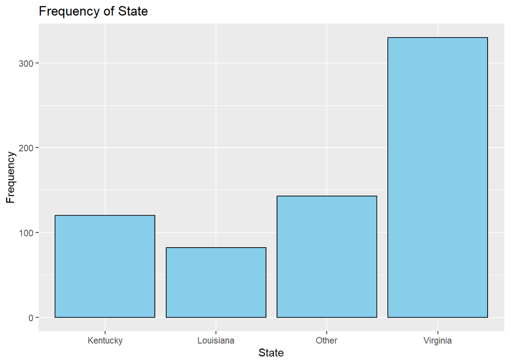

```r
# 'State' 컬럼의 빈도수를 계산합니다.
State_freq <- table(df_imp$State)

# 빈도수를 데이터프레임으로 변환합니다.
State_freq_df <- as.data.frame(State_freq)
names(State_freq_df) <- c("State", "Frequency")

# 히스토그램을 그립니다.
ggplot(State_freq_df, aes(x = State, y = Frequency)) +
  geom_bar(stat = "identity", fill = "skyblue", color = "black") +
  labs(title = "Frequency of State", x = "State", y = "Frequency")
```

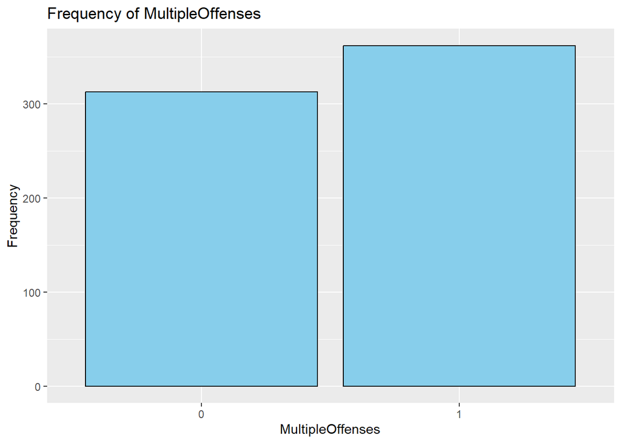

```r
# 'MultipleOffenses' 컬럼의 빈도수를 계산합니다.
MultipleOffenses_freq <- table(df_imp$MultipleOffenses)

# 빈도수를 데이터프레임으로 변환합니다.
MultipleOffenses_freq_df <- as.data.frame(MultipleOffenses_freq)
names(MultipleOffenses_freq_df) <- c("MultipleOffenses", "Frequency")

# 히스토그램을 그립니다.
ggplot(MultipleOffenses_freq_df, aes(x = MultipleOffenses, y = Frequency)) +
  geom_bar(stat = "identity", fill = "skyblue", color = "black") +
  labs(title = "Frequency of MultipleOffenses", x = "MultipleOffenses", y = "Frequency")
```

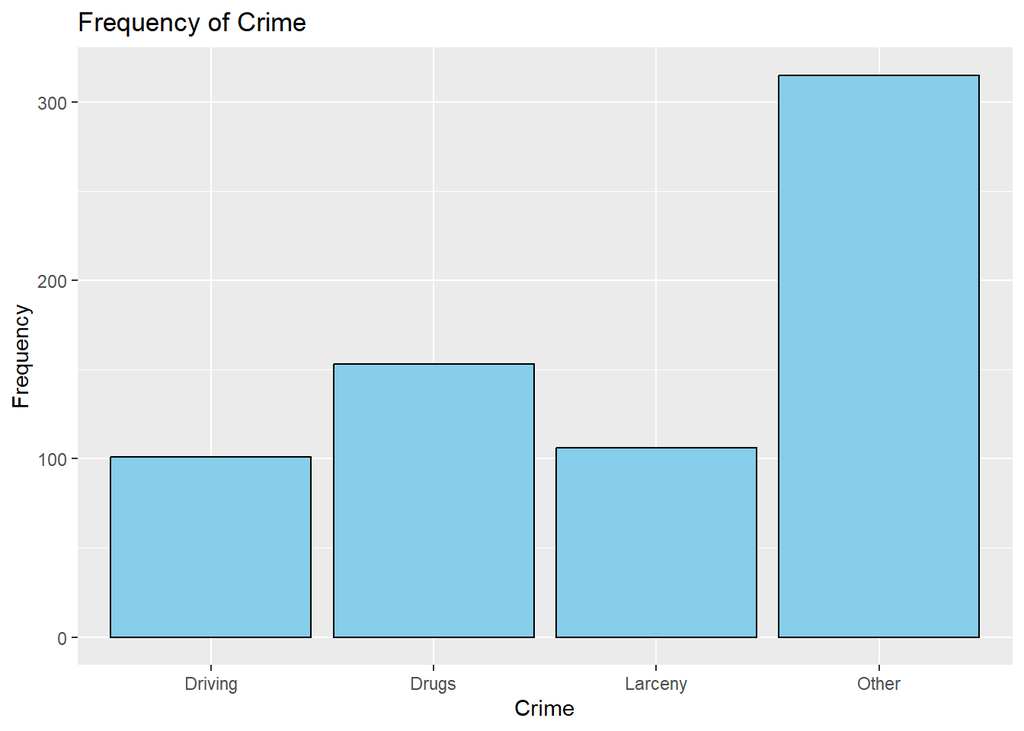

```r
# 'Crime' 컬럼의 빈도수를 계산합니다.
Crime_freq <- table(df_imp$Crime)

# 빈도수를 데이터프레임으로 변환합니다.
Crime_freq_df <- as.data.frame(Crime_freq)
names(Crime_freq_df) <- c("Crime", "Frequency")

# 히스토그램을 그립니다.
ggplot(Crime_freq_df, aes(x = Crime, y = Frequency)) +
  geom_bar(stat = "identity", fill = "skyblue", color = "black") +
  labs(title = "Frequency of Crime", x = "Crime", y = "Frequency")
```

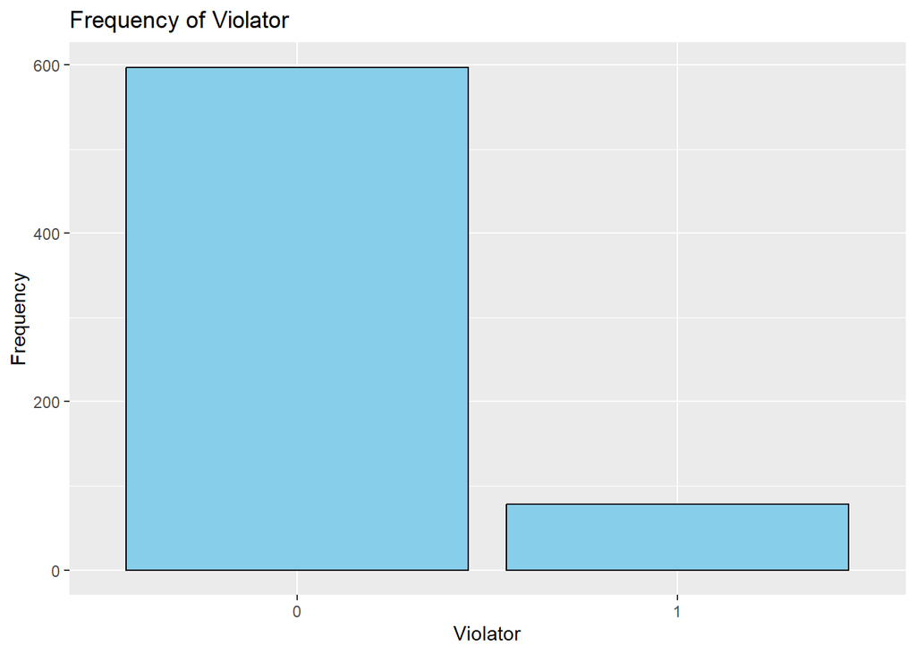

```r
# 'Violator' 컬럼의 빈도수를 계산합니다.
Violator_freq <- table(df_imp$Violator)

# 빈도수를 데이터프레임으로 변환합니다.
Violator_freq_df <- as.data.frame(Violator_freq)
names(Violator_freq_df) <- c("Violator", "Frequency")

# 히스토그램을 그립니다.
ggplot(Violator_freq_df, aes(x = Violator, y = Frequency)) +
  geom_bar(stat = "identity", fill = "skyblue", color = "black") +
  labs(title = "Frequency of Violator", x = "Violator", y = "Frequency")
```

범주형 컬럼들의 데이터 분포를 히스토그램으로 그려보았을 때 Male, State, Frequency, Violator 컬럼의 클래스 불균형이 심하다는 것을 확인할 수 있다.

Stratified sampling을 통해 traing set과 test set을 70:30 비율로 분할한다. 그리고 training set을 활용하여 가석방 조건 위반 여부(Violator)를 예측하기 위한 logistic regression model을 수립하자. 이때 모든 feature 변수를 모델에 포함시킨다.

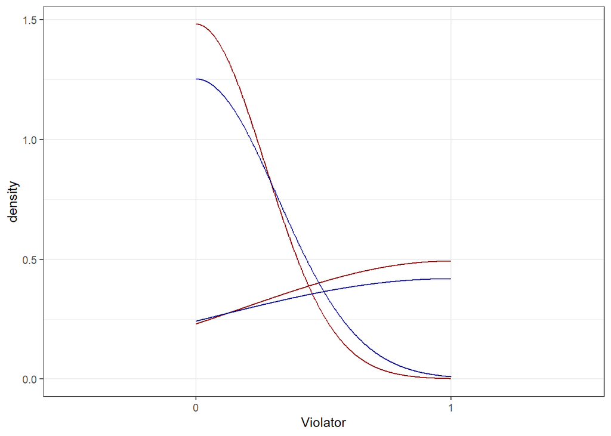

```r
# Stratified sampling을 통해 traing set과 test set을 7:3 비율로 분할

set.seed(123)

split <- initial_split(df_imp, prop = 0.7, strata = "Violator")
df_train <- training(split)
df_test <- testing(split)

ggplot(df_train, aes(x = Violator)) + geom_density(color="darkred") +
geom_density(data = df_test, aes(x = Violator), color="darkblue") +
theme_bw()
```

```r
#logistic regression model을 수립 , 모든 feature를 포함
model <-glm(Violator~. , family = "binomial" , data = df_train )
summary(model)
```

```
##
## Call:
## glm(formula = Violator ~ ., family = "binomial", data = df_train)
##
## Coefficients:
##                    Estimate Std. Error z value Pr(>|z|)
## (Intercept)       -1.660861   1.427109  -1.164   0.2445
## Male1              0.050979   0.451731   0.113   0.9101
## RaceWhite1        -0.914462   0.405390  -2.256   0.0241 *
## Age               -0.003789   0.017537  -0.216   0.8289
## StateLouisiana     0.607311   0.599411   1.013   0.3110
## StateOther        -0.114754   0.538756  -0.213   0.8313
## StateVirginia     -3.811659   0.779103  -4.892 9.96e-07 ***
## TimeServed        -0.217389   0.119512  -1.819   0.0689 .
## MaxSentence        0.081833   0.052036   1.573   0.1158
## MultipleOffenses1  1.781361   0.405812   4.390 1.14e-05 ***
## CrimeDrugs        -0.335724   0.689691  -0.487   0.6264
## CrimeLarceny      -0.165958   0.750918  -0.221   0.8251
## CrimeOther         0.104981   0.590877   0.178   0.8590
## ---
## Signif. codes:  0 '***' 0.001 '**' 0.01 '*' 0.05 '.' 0.1 ' ' 1
##
## (Dispersion parameter for binomial family taken to be 1)
##
##     Null deviance: 335.47  on 470  degrees of freedom
## Residual deviance: 229.05  on 458  degrees of freedom
## AIC: 255.05
##
## Number of Fisher Scoring iterations: 6
```

1. Logistic regression의 결과를 분석해보자.

AIC 값은 모델의 적합도와 모델의 복잡성을 모두 고려하므로 AIC 값이 작을수록 더 좋은 모델이다. 주어진 데이터에 대한 해당 모델의 적합도와 모델의 복잡성을 고려할 때, AIC 값이 255.05인 것은 비교적 적합도가 높으면서도 간단한 모델을 의미하므로 모델이 데이터를 잘 학습하였다고 볼 수 있다.

RaceWhite1, StateVirginia, MultipleOffenses1 컬럼은은 p-value가 유의수준인 0.05보다 작으므로, 유의미한 변수들이라 할 수 있다. Male1, Age, StateLouisiana, StateOther, TimeServed, MaxSentence, CrimeDrugs, CrimeLarceny, CrimeOther 컬럼은은 p-value가 유의수준인 0.05보다 크므로, 유의미하지 않은 변수들이라 할 수 있다.

Null deviance와 Residual deviance는 각각 모델이 종속 변수를 얼마나 잘 설명하는지를 나타내는 척도이다. Residual deviance가 더 작은 모델이 더 좋은 적합도를 보인다. 해당 모델의 Residual deviance는 229.05로, Null deviance에 비해 낮은 값으로 데이터를 잘 설명하는 것이라 할 수 있다.

2. Logistic regression의 결과로부터, 중복 범죄로 인한 수감자의 가석방 조건 위반 확률에 대해 어떠한 해석을 할 수 있는가?

중복 범죄(MultipleOffenses) 변수의 계수는 1.781361로 나타난다. 이는 중복 범죄자가 가석방 조건을 위반할 로그 오즈의 증가를 나타낸다. 여기서 로그 오즈가 양수인 경우, 해당 변수의 값이 증가할수록 가석방 조건 위반의 가능성이 더 높아진다는 것을 의미한니다. 해당 모델에서 중복 범죄자는 가석방 조건 위반이 더 자주 발생할 가능성이 있다.

3. Logistic regression의 결과로부터, Louisiana state의 수감자의 가석방 조건 위반 확률에 대해 어떠한 해석 을 할 수 있는가?

’StateLouisiana’의 계수는 0.607311이며 이는 Louisiana 주에 속한 수감자가 다른 변수가 동일할 때, 가석방 조건 위반에 대해 로그 오즈를 얼마나 증가시키는지를 나타낸다. p-value가 0.3110으로 나타나 0.05보다 크므로 통계적으로 유의미하지 않은 결과이다. 따라서, Louisiana 주에 속한 수감자가 가석방 조건 위반을 할 확률이 다른 변수가 동일한 경우에 유의하게 증가한다고 할 수 없다.

4. (남성, 백인, 40세, Kentucky state, 4개월 수감, 12개월 형량, 중복 범죄, 마약 범죄)의 정보를 가진 수감자가 가석방 후 조건을 위반할 확률은 얼마인가?

```r
logit_p <- -1.660861 + (-0.217389 * 4) + (-0.003789 * 40) + (0.050979 * 1) + ( -0.914462 * 1) + (0.081833 * 12) + ( 1.781361 * 1) + (-0.335724 * 1)

p <- exp(logit_p) / (1 + exp(logit_p))

p
```

```
## [1] 0.2464146
```

5. 다양한 threshold 값에 대해 training set의 가석방 조건 위반 여부를 예측해보자. 이때 값의 변화에 따른 accuracy, sensitivity, specificity 값을 변화를 그래프로 그려보자.

```r
# prob for test set
train_prob <- predict(model, df_train, type = "response")
train_pred <- ifelse(train_prob >= 0.5, 1, 0)

# 두 벡터를 팩터로 변환하고 레벨을 명시적으로 지정
train_pred_factor <- factor(train_pred, levels = c("0", "1"))
violator_factor <- factor(df_train$Violator, levels = c("0", "1"))


conf_matrix <- confusionMatrix(train_pred_factor, violator_factor, positive = "1")

# 혼동 행렬 출력
print(conf_matrix)
```

```
## Confusion Matrix and Statistics
##
##           Reference
## Prediction   0   1
##          0 405  35
##          1  12  19
##
##                Accuracy : 0.9002
##                  95% CI : (0.8695, 0.9258)
##     No Information Rate : 0.8854
##     P-Value [Acc > NIR] : 0.174055
##
##                   Kappa : 0.3966
##
##  Mcnemar's Test P-Value : 0.001332
##
##             Sensitivity : 0.35185
##             Specificity : 0.97122
##          Pos Pred Value : 0.61290
##          Neg Pred Value : 0.92045
##              Prevalence : 0.11465
##          Detection Rate : 0.04034
##    Detection Prevalence : 0.06582
##       Balanced Accuracy : 0.66154
##
##        'Positive' Class : 1
##
```

```r
# prob for test set
train_prob <- predict(model, df_train, type = "response")
train_pred <- ifelse(train_prob >= 0.3, 1, 0)

# 두 벡터를 팩터로 변환하고 레벨을 명시적으로 지정
train_pred_factor <- factor(train_pred, levels = c("0", "1"))
violator_factor <- factor(df_train$Violator, levels = c("0", "1"))


conf_matrix <- confusionMatrix(train_pred_factor, violator_factor, positive = "1")

# 혼동 행렬 출력
print(conf_matrix)
```

```
## Confusion Matrix and Statistics
##
##           Reference
## Prediction   0   1
##          0 390  26
##          1  27  28
##
##                Accuracy : 0.8875
##                  95% CI : (0.8554, 0.9146)
##     No Information Rate : 0.8854
##     P-Value [Acc > NIR] : 0.4786
##
##                   Kappa : 0.4501
##
##  Mcnemar's Test P-Value : 1.0000
##
##             Sensitivity : 0.51852
##             Specificity : 0.93525
##          Pos Pred Value : 0.50909
##          Neg Pred Value : 0.93750
##              Prevalence : 0.11465
##          Detection Rate : 0.05945
##    Detection Prevalence : 0.11677
##       Balanced Accuracy : 0.72689
##
##        'Positive' Class : 1
##
```

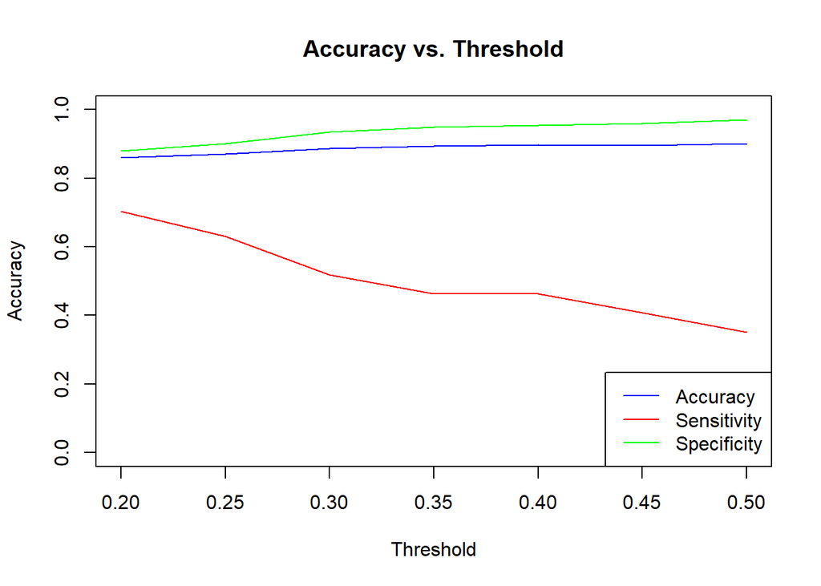

```r
thresholds <- seq(0.2, 0.5, by = 0.05)

accuracy_values <- c()
sensitivity_values <- c()
specificity_values <- c()

for (threshold in thresholds) {
    train_pred <- ifelse(train_prob >= threshold, 1, 0)
    train_pred_factor <- factor(train_pred, levels = c("0", "1"))
    conf_matrix <- confusionMatrix(train_pred_factor, violator_factor, positive = "1")
    accuracy_values <- c(accuracy_values, conf_matrix$overall['Accuracy'])
    sensitivity_values <- c(sensitivity_values, conf_matrix$byClass['Sensitivity'])
    specificity_values <- c(specificity_values, conf_matrix$byClass['Specificity'])
}

# Plotting
plot(thresholds, accuracy_values, type = 'l', col = 'blue', xlab = 'Threshold', ylab = 'Accuracy', main = 'Accuracy vs. Threshold', ylim = c(0, 1))
lines(thresholds, sensitivity_values, type = 'l', col = 'red')
lines(thresholds, specificity_values, type = 'l', col = 'green')
legend("bottomright", legend=c("Accuracy", "Sensitivity", "Specificity"), col=c("blue", "red", "green"), lty=1)
```

t값의 증가에 따라 accuracy와 specify가 증가하며, sensitivity는 떨어지는 경향을 볼 수 있다.

6. Target의 불균형이 큰 경우, F1 score를 분류모델의 성능지표로 사용할 수 있다. F1 score가 의미하는 것이 무 엇인지 찾아보자. 그리고 현재 모델에 대해서 여러 threshold 값에 대한 F1 score를 계산해보자. (F1 score 는 confusionMatrix() 함수에 mode=“everything”을 인수로 추가하여 출력할 수 있다.)

```r
# Function to calculate F1 score for given threshold
calculate_f1_score <- function(threshold, train_prob, violator_factor) {
    train_pred <- ifelse(train_prob >= threshold, "1", "0")
    train_pred_factor <- factor(train_pred, levels = c("0", "1"))
    matrix <- confusionMatrix(train_pred_factor, violator_factor, positive = "1", mode = "everything")
    f1_score <- matrix$byClass['F1']
    return(f1_score)
}

# 모델 예측
train_prob <- predict(model, df_train, type = "response")
violator_factor <- factor(df_train$Violator, levels = c("0", "1"))

# 임계값에 따른 F1 점수 계산
thresholds <- seq(0.2, 0.5, by = 0.05)
f1_scores <- sapply(thresholds, function(threshold) {
    calculate_f1_score(threshold, train_prob, violator_factor)
})

# 결과 출력
for (i in seq_along(thresholds)) {
    print(paste("F1 Score at t =", thresholds[i], ":", f1_scores[i]))
}
```

```
## [1] "F1 Score at t = 0.2 : 0.535211267605634"
## [1] "F1 Score at t = 0.25 : 0.527131782945736"
## [1] "F1 Score at t = 0.3 : 0.513761467889908"
## [1] "F1 Score at t = 0.35 : 0.5"
## [1] "F1 Score at t = 0.4 : 0.510204081632653"
## [1] "F1 Score at t = 0.45 : 0.473118279569892"
## [1] "F1 Score at t = 0.5 : 0.447058823529412"
```

따라서 이러한 결과를 고려할 때, 클래스 불균형이 존재하는 경우에는 F1 점수를 분류 모델의 성능지표로 사용하는 것이 적절할 수 있다. F1 점수는 모델이 얼마나 정확하게 예측하는지와 동시에, 다수 클래스에 대한 재현율을 고려하여 모델의 전반적인 성능을 평가할 수 있는 지표이다.

7. 수감자의 가석방 여부를 결정하는 심사위원회에서 이 모델을 사용하여 가석방 조건 위반 여부를 예측한다고 하 자. e), f)의 결과를 바탕으로, 심사위원회의 의사결정을 위해서는 threshold 를 어느 정도의 값으로 사용하는 것이 합리적일지 생각해보자.

accuracy와 specificity는 임계값이 클수록 증가하는 경향을 보이며, sensitivity와 F1 점수는 임계값이 클수록 감소하는 경향을 보인다. 따라서 심사위원회가 가석방 조건 위반 여부를 예측하는데 높은 정확성을 중요시하는 경우, 더 높은 임계값을 선택하는 것이 합리적이다. 이는 모델이 긍정 클래스(가석방 조건 위반)를 더 조심스럽게 예측하도록 하여 잘못된 긍정 예측을 최소화하는 데 도움이 될 수 있다.

3번의 logistic regression model에 Lasso regularization을 적용해본다. Target 변수의 불균형이 크므로 accuracy보다는 AUC를 기준으로 Cross validation의 성능을 평가하고, CV 결과를 바탕으로 가장 적합한 모델을 선택하자.

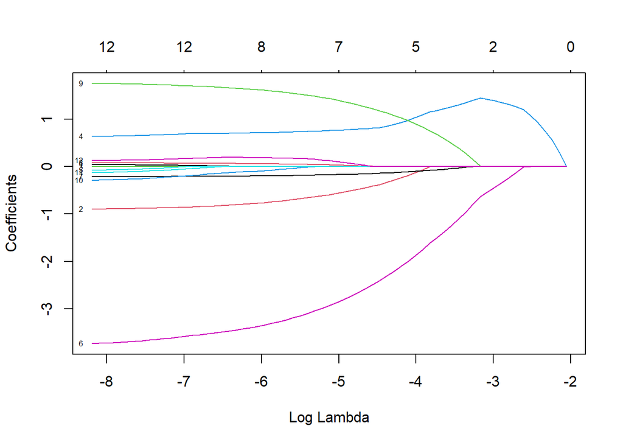

```r
trainX <- model.matrix(Violator~., df_train)[, -1]
trainY <- df_train$Violator
lasso_model <- glmnet(x=trainX, y=trainY, alpha = 1, family="binomial")

plot(lasso_model, xvar="lambda", label = TRUE)
```

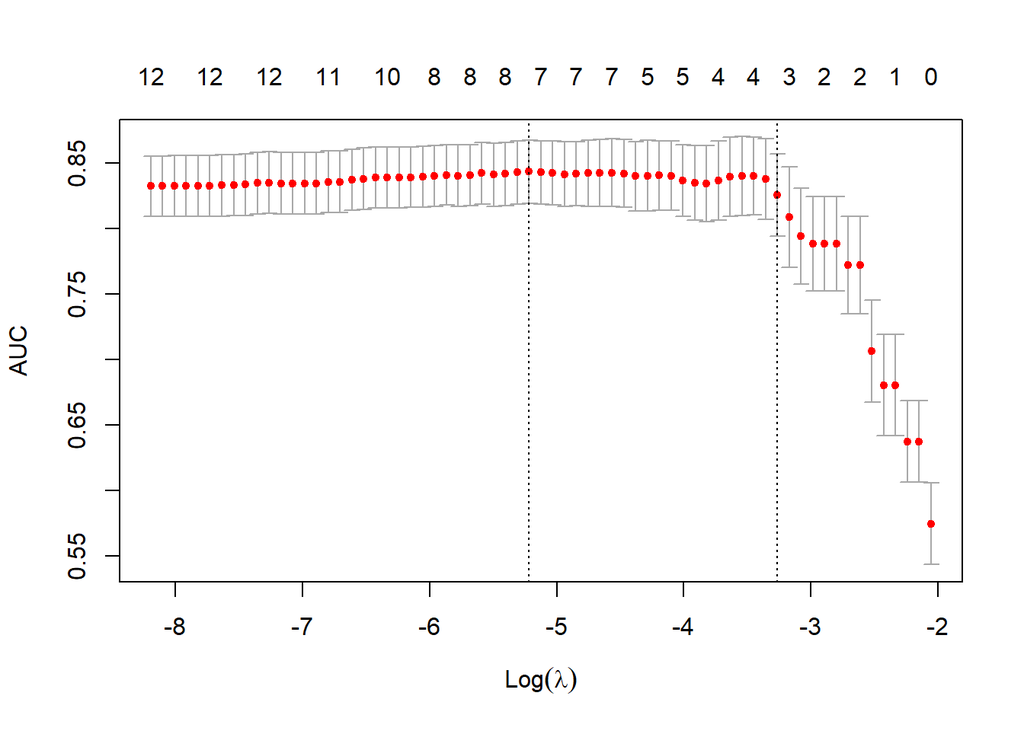

```r
set.seed(123)
cv_lasso <- cv.glmnet(x = trainX, y = trainY, alpha = 1, family = "binomial", type.measure = "auc", nfolds = 10)
plot(cv_lasso)
```

```r
# perforamnce measure 출력
cv_lasso$cvm
```

```
##  [1] 0.5744186 0.6373685 0.6373685 0.6804056 0.6804056 0.7064384 0.7719671
##  [8] 0.7719671 0.7883608 0.7883608 0.7883608 0.7939946 0.8087382 0.8257117
## [15] 0.8378504 0.8401183 0.8401503 0.8397447 0.8367258 0.8345944 0.8351576
## [22] 0.8369779 0.8404793 0.8406915 0.8404019 0.8399975 0.8422528 0.8428288
## [29] 0.8424938 0.8423612 0.8419459 0.8415019 0.8425847 0.8428468 0.8434496
## [36] 0.8428771 0.8418217 0.8413465 0.8425081 0.8407643 0.8404232 0.8410632
## [43] 0.8400155 0.8397891 0.8392181 0.8390147 0.8388772 0.8388772 0.8381212
## [50] 0.8372235 0.8357938 0.8357938 0.8346334 0.8346334 0.8346334 0.8346334
## [57] 0.8350391 0.8347709 0.8335337 0.8331773 0.8329535 0.8326853 0.8326853
## [64] 0.8326853 0.8326853 0.8323936 0.8323936
```

```r
# cv에 사용된 lambda 출력
cv_lasso$lambda
```

```
##  [1] 0.1281307704 0.1167479859 0.1063764166 0.0969262289 0.0883155699
##  [6] 0.0804698581 0.0733211377 0.0668074899 0.0608724966 0.0554647518
## [11] 0.0505374161 0.0460478113 0.0419570507 0.0382297019 0.0348334806
## [16] 0.0317389702 0.0289193675 0.0263502506 0.0240093670 0.0218764410
## [21] 0.0199329983 0.0181622057 0.0165487254 0.0150785822 0.0137390425
## [26] 0.0125185039 0.0114063945 0.0103930818 0.0094697891 0.0086285191
## [31] 0.0078619853 0.0071635482 0.0065271583 0.0059473035 0.0054189615
## [36] 0.0049375559 0.0044989170 0.0040992456 0.0037350799 0.0034032657
## [41] 0.0031009290 0.0028254510 0.0025744457 0.0023457391 0.0021373501
## [46] 0.0019474738 0.0017744656 0.0016168269 0.0014731925 0.0013423181
## [51] 0.0012230703 0.0011144161 0.0010154144 0.0009252078 0.0008430149
## [56] 0.0007681238 0.0006998858 0.0006377099 0.0005810575 0.0005294379
## [61] 0.0004824041 0.0004395487 0.0004005004 0.0003649210 0.0003325025
## [66] 0.0003029639 0.0002760494
```

```r
# nonzero 변수의 수 출력
cv_lasso$nzero
```

```
##  s0  s1  s2  s3  s4  s5  s6  s7  s8  s9 s10 s11 s12 s13 s14 s15 s16 s17 s18 s19
##   0   1   1   1   1   1   2   2   2   2   2   2   3   3   4   4   4   4   4   4
## s20 s21 s22 s23 s24 s25 s26 s27 s28 s29 s30 s31 s32 s33 s34 s35 s36 s37 s38 s39
##   5   5   5   5   5   5   6   7   7   7   7   7   7   7   7   7   8   8   8   8
## s40 s41 s42 s43 s44 s45 s46 s47 s48 s49 s50 s51 s52 s53 s54 s55 s56 s57 s58 s59
##   8   8   8   8   8   9  10  10  10  11  11  11  11  12  12  12  12  12  12  12
## s60 s61 s62 s63 s64 s65 s66
##  12  12  12  12  12  12  12
```

```r
# 1-se rule 적용하여 lambda 선택
coef(cv_lasso, s = cv_lasso$lambda.1se)
```

```
## 13 x 1 sparse Matrix of class "dgCMatrix"
##                           s1
## (Intercept)       -2.1300850
## Male1              .
## RaceWhite1         .
## Age                .
## StateLouisiana     1.4035171
## StateOther         .
## StateVirginia     -0.7956723
## TimeServed         .
## MaxSentence        .
## MultipleOffenses1  0.1522860
## CrimeDrugs         .
## CrimeLarceny       .
## CrimeOther         .
```

1. 어떠한 기준으로 모델을 선택하였으며, 최종적으로 모델에 어떠한 변수들이 포함되었는가?

모델 선택 과정에서 1-SE 규칙을 적용하여 최적의 lambda 값을 결정하였다. 이는 모델의 복잡성을 줄이고 일반화 성능 향상에 도움이 된다. 따라서 선택된 최종 모델은 1-SE 규칙에 따라 lambda 값이 선택된 결과이다. 해당 모델은 Lasso 정규화를 적용한 Logistic Regression 모델로 StateLouisiana, StateVirginia, MultipleOffenses1 변수가 포함되었다.

2. 3번의 logistic regression model과 Lasso를 적용한 model의 성능을 나타내는 ROC Curve를 하나의 그래프로 동시에 시각화하고, AUC값을 비교해 보자. Training set과 Test set에 대해 각각 비교해본다. 이 결과로부터 Lasso regularization의 효과가 있는지 분석해보자.

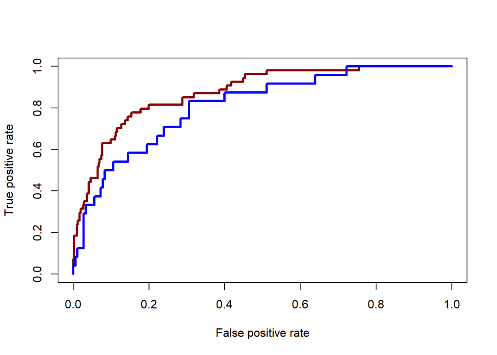

```r
pred_train <- prediction(train_prob, df_train$Violator)
perf_train <- performance(pred_train, "tpr", "fpr")
plot(perf_train, col = "darkred", lwd = 3)

auc_train <- performance(pred_train, "auc")

test_prob <- predict(model, df_test, type = "response")
pred_test <- prediction(test_prob, df_test$Violator)
perf_test <- performance(pred_test, "tpr", "fpr")
plot(perf_test, col = "blue", lwd = 3, add = TRUE)
```

```r
auc_train <- performance(pred_train, "auc")
print(auc_train@y.values)
```

```
## [[1]]
## [1] 0.8762323
```

```r
auc_test <- performance(pred_test, "auc")
print(auc_test@y.values)
```

```
## [[1]]
## [1] 0.8115741
```

5. 마지막으로 SVM을 적용해보자. Linear, polynomial, RBF kernel들을 사용하여 SVM 모델을 만들어본다. CV를 활용한 parameter tuning을 통해 좋은 성능의 모델을 찾아보자.

```r
svmfit<-svm(Violator~. , data = df_train , kernel = "linear" , cost=10 , scale = TRUE)

# support vector의 index 출력
svmfit$index
```

```
##   [1]   3   7  24  26  29  30  31  32  33  34  35  36  37  38  42  49  50  54
##  [19]  59  68  80  85  95 111 112 113 114 115 116 117 118 119 120 121 122 123
##  [37] 124 125 126 127 128 129 130 131 132 134 136 137 140 142 146 149 154 201
##  [55] 204 234 241 312 402 418 419 420 421 422 423 424 425 426 427 428 429 430
##  [73] 431 432 433 434 435 436 437 438 439 440 441 442 443 444 445 446 447 448
##  [91] 449 450 451 452 453 454 455 456 457 458 459 460 461 462 463 464 465 466
## [109] 467 468 469 470 471
```

```r
summary(svmfit)
```

```
##
## Call:
## svm(formula = Violator ~ ., data = df_train, kernel = "linear", cost = 10,
##     scale = TRUE)
##
##
## Parameters:
##    SVM-Type:  C-classification
##  SVM-Kernel:  linear
##        cost:  10
##
## Number of Support Vectors:  113
##
##  ( 59 54 )
##
##
## Number of Classes:  2
##
## Levels:
##  0 1
```

데이터에 대해서 cost가 10일때, support vector가 113개임을 확인할 수 있다. 할 수 있다.

```r
set.seed(123)

tune.out <- tune(svm, Violator~. , data = df_train , kernel = "linear",ranges = list(cost = 10^seq(-1, 1)),
                 tunecontrol = tune.control(cross = 10))

# tuning 결과 출력
summary(tune.out)
```

```
##
## Parameter tuning of 'svm':
##
## - sampling method: 10-fold cross validation
##
## - best parameters:
##  cost
##   0.1
##
## - best performance: 0.1144947
##
## - Detailed performance results:
##   cost     error dispersion
## 1  0.1 0.1144947 0.04200692
## 2  1.0 0.1166223 0.04441503
## 3 10.0 0.1187943 0.03727623
```

```r
# tuning으로 찾은 best model 추출
bestmodel <- tune.out$best.model

bestmodel
```

```
##
## Call:
## best.tune(METHOD = svm, train.x = Violator ~ ., data = df_train,
##     ranges = list(cost = 10^seq(-1, 1)), tunecontrol = tune.control(cross = 10),
##     kernel = "linear")
##
##
## Parameters:
##    SVM-Type:  C-classification
##  SVM-Kernel:  linear
##        cost:  0.1
##
## Number of Support Vectors:  117
```

10-fold CV를 적용하여 파라미티터를 튜닝하였다.best parameters는 0.1 일때, 0.1144947로 best performance 였임을 확인할 수 있다.그리고 그때의 Support Vector의 갯수는 117개임을 알 수 있다.

```r
svmfit_rbf <- svm(Violator ~ ., data = df_train, kernel = "radial", gamma = 1 , cost =1)

summary(svmfit_rbf)
```

```
##
## Call:
## svm(formula = Violator ~ ., data = df_train, kernel = "radial", gamma = 1,
##     cost = 1)
##
##
## Parameters:
##    SVM-Type:  C-classification
##  SVM-Kernel:  radial
##        cost:  1
##
## Number of Support Vectors:  329
##
##  ( 277 52 )
##
##
## Number of Classes:  2
##
## Levels:
##  0 1
```

gamma 파라미터 값을 1로 지정하고 RBF Kernel을 사용하였다. support vector는 329개가 나왔음을 확인할 수 있다.

```r
set.seed(123)
rbf_tune_result <- tune(svm, Violator ~ ., data = df_train, kernel = "radial",ranges = list(cost = 10^seq(-1, 1),
                    gamma = 10^seq(-1, 1)),tunecontrol = tune.control(cross = 10))

# 튜닝 결과 요약
summary(rbf_tune_result)
```

```
##
## Parameter tuning of 'svm':
##
## - sampling method: 10-fold cross validation
##
## - best parameters:
##  cost gamma
##     1     1
##
## - best performance: 0.09760638
##
## - Detailed performance results:
##   cost gamma      error dispersion
## 1  0.1   0.1 0.11449468 0.04200692
## 2  1.0   0.1 0.11236702 0.04527031
## 3 10.0   0.1 0.10820035 0.04829208
## 4  0.1   1.0 0.11449468 0.04200692
## 5  1.0   1.0 0.09760638 0.04259104
## 6 10.0   1.0 0.12522163 0.03517495
## 7  0.1  10.0 0.11449468 0.04200692
## 8  1.0  10.0 0.11023936 0.04497071
## 9 10.0  10.0 0.10394504 0.04389529
```

```r
print(rbf_tune_result$best.parameters)
```

```
##   cost gamma
## 5    1     1
```

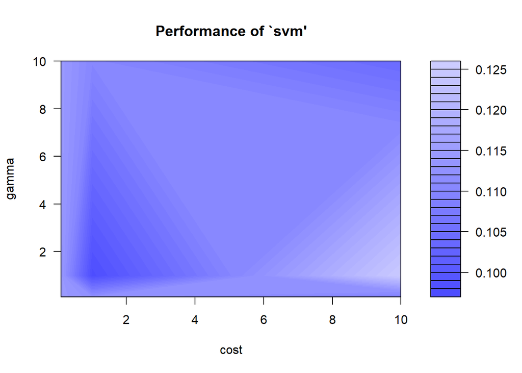

```r
plot(rbf_tune_result)
```

10-fold CV를 적용하여 파라미티터를 튜닝하였다.best parameters는 cost가 1, gamma 1이며 best performance는 0.09760638 이다.

```r
#Polynomial kernel SVM
svmfit_pol <- svm(Violator ~ ., data = df_train, kernel = "polynomial" , cost =1 , degree=2)

summary(svmfit_pol)
```

```
##
## Call:
## svm(formula = Violator ~ ., data = df_train, kernel = "polynomial",
##     cost = 1, degree = 2)
##
##
## Parameters:
##    SVM-Type:  C-classification
##  SVM-Kernel:  polynomial
##        cost:  1
##      degree:  2
##      coef.0:  0
##
## Number of Support Vectors:  127
##
##  ( 73 54 )
##
##
## Number of Classes:  2
##
## Levels:
##  0 1
```

cost= 1, degree=2 일때 support vector 가 127개임을 알 수 있다.

```r
set.seed(123)

pol_tune <- tune(svm , Violator~. , data = df_train ,kernel = "polynomial",
                 ranges=list(cost=c(0.1, 1, 10), degree=c(2, 3, 4)), tunecontrol = tune.control(cross = 10))
summary(pol_tune)
```

```
##
## Parameter tuning of 'svm':
##
## - sampling method: 10-fold cross validation
##
## - best parameters:
##  cost degree
##    10      2
##
## - best performance: 0.103945
##
## - Detailed performance results:
##   cost degree     error dispersion
## 1  0.1      2 0.1144947 0.04200692
## 2  1.0      2 0.1166223 0.04208916
## 3 10.0      2 0.1039450 0.03034487
## 4  0.1      3 0.1144947 0.04200692
## 5  1.0      3 0.1081117 0.04455636
## 6 10.0      3 0.1060727 0.02599637
## 7  0.1      4 0.1144947 0.04200692
## 8  1.0      4 0.1081117 0.04455636
## 9 10.0      4 0.1060284 0.03547872
```

10-fold CV를 적용하여 파라미티터를 튜닝하였다.best performance는 0.103945 이다.

1. 가장 좋은 성능의 SVM 모델은 무엇인가?

RBF Kernel SVM의error가 0.09760638로 가장 낮았기 때문에 가장 성능 좋은 SVM모델은 RBF Kernel SVM 모델이라고 할 수 있다.

2. 위 모델의 training set과 test set에 대한 성능을 평가해보자. 본 예측 문제에 대해 SVM 모델이 logistic regression 모델에 비해 우수하다고 할 수 있는가?

```r
#RBF SVM 모델 성능평가
bestmodel_rbf<-rbf_tune_result$best.model
predictions_rbf <- predict(bestmodel_rbf, df_test)
confusionMatrix(predictions_rbf, df_test$Violator)
```

```
## Confusion Matrix and Statistics
##
##           Reference
## Prediction   0   1
##          0 179  24
##          1   1   0
##
##                Accuracy : 0.8775
##                  95% CI : (0.8244, 0.9191)
##     No Information Rate : 0.8824
##     P-Value [Acc > NIR] : 0.637
##
##                   Kappa : -0.0095
##
##  Mcnemar's Test P-Value : 1.083e-05
##
##             Sensitivity : 0.9944
##             Specificity : 0.0000
##          Pos Pred Value : 0.8818
##          Neg Pred Value : 0.0000
##              Prevalence : 0.8824
##          Detection Rate : 0.8775
##    Detection Prevalence : 0.9951
##       Balanced Accuracy : 0.4972
##
##        'Positive' Class : 0
##
```

가장 성능이 좋았던 RBF Kernel SVM 모델의 성능평가를 실시하였을 때 Accuracy : 0.8775, Sensitivity : 0.9944, Specificity : 0.0000이 나왔다. 기존 logistic Regression의 지표들이 더 우수함을 확인 할 수 있다. 따라서 SVM 모델이 logistic regression 모델에 비해 우수하다고 할 수 없다.

3. Target 변수의 불균형이 큰 경우 SVM의 성능이 좋지 않을 수 있는가? 만약 그렇다면 원인이 무엇일지 생각해보자.

SVM은 모델을 훈련시킬 때 클래스 간의 균형을 유지하는 것이 중요하다. Target 변수의 불균형이 심한 경우 모델이 소수 클래스에 대해 충분한 학습을 수행하지 못 할 수 있다. 클래스 간의 불균형이 심할 경우, 소수 클래스에 대한 결정 경계를 학습하는 데 어려움을 겪을 수 있다. 이로 인해 소수 클래스를 올바르게 분류하는 데 어려움이 생길 수 있다.